# Phylogenetic community assembly with the Fish Tree of Life

Jonathan Chang

Here’s a quick example to show how we could use the `fishtree` package to conduct some phylogenetic community analyses. First, we load `fishtree` and ensure that the other packages that we need are installed.

```r
library(ape)
library(fishtree)
loadNamespace("rfishbase")
```

```
#> <environment: namespace:rfishbase>
```

```r
loadNamespace("picante")
```

```
#> <environment: namespace:picante>
```

```r
loadNamespace("geiger")
```

```
#> <environment: namespace:geiger>
```

Next we’ll start downloading some data from `rfishbase`. We’ll be seeing if reef-associated ray-finned fish species are clustered or overdispersed in the Atlantic, Pacific, and Indian Oceans.

```r
# Get reef-associated species from the `species` table
reef_species <- rfishbase::species(fields = c("Species", "DemersPelag"))
reef_species <- reef_species[reef_species$DemersPelag == "reef-associated", ]

# Get native and endemic species from the Atlantic, Pacific, and Indian Oceans
eco <- rfishbase::ecosystem(species_list = reef_species$Species)
valid_idx <- eco$Status %in% c("native", "endemic") & eco$EcosystemName %in% c("Atlantic Ocean", "Pacific Ocean", "Indian Ocean")
eco <- eco[valid_idx, c("Species", "EcosystemName")]

# Retrieve the phylogeny of only native reef species across all three oceans.
phy <- fishtree_phylogeny(species = eco$Species)
```

We’ll have to clean up the data in a few ways before sending it to `picante` for analysis. First, we’ll need to convert our species-by-site data frame into a presence-absence matrix. We’ll use `base::table` for this, and use `unclass` to convert the `table` into a standard `matrix` object.

```r
sample_matrix <- unclass(table(eco))
dimnames(sample_matrix)$Species <- gsub(" ", "_", dimnames(sample_matrix)$Species, fixed = TRUE)
```

Next, we’ll use `geiger::name.check` to ensure the tip labels of the phylogeny and the rows of the data matrix match each other.

```r
nc <- geiger::name.check(phy, sample_matrix)
sample_matrix <- sample_matrix[!rownames(sample_matrix) %in% nc$data_not_tree, ]
```

Finally, we’ll generate the cophenetic matrix based on the phylogeny, and transpose the presence-absence matrix since `picante` likes its columns to be species and its rows to be sites.

```r
cophen <- cophenetic(phy)
sample_matrix <- t(sample_matrix)
```

We’ll run `picante::ses.mpd` and `picante::ses.mntd` with only 100 iterations, to speed up the analysis. For a real analysis you would likely increase this to 1000, and possibly test other null models if your datasets have e.g., abundance information.

```r
picante::ses.mpd(sample_matrix, cophen, null.model = "taxa.labels", runs = 99)
```

```
#>                ntaxa  mpd.obs mpd.rand.mean mpd.rand.sd mpd.obs.rank
#> Atlantic Ocean   623 238.1682      231.3588   2.5213665          100
#> Indian Ocean    1213 233.1537      231.9486   1.3943958           76
#> Pacific Ocean   1497 231.6829      231.7546   0.9395066           47
#>                  mpd.obs.z mpd.obs.p runs
#> Atlantic Ocean  2.70068771      1.00   99
#> Indian Ocean    0.86421415      0.76   99
#> Pacific Ocean  -0.07634417      0.47   99
```

```r
picante::ses.mntd(sample_matrix, cophen, null.model = "taxa.labels", runs = 99)
```

```
#>                ntaxa mntd.obs mntd.rand.mean mntd.rand.sd mntd.obs.rank
#> Atlantic Ocean   623 41.86956       48.22864    1.1668943             1
#> Indian Ocean    1213 34.99129       38.02963    0.7548866             1
#> Pacific Ocean   1497 34.08644       34.99204    0.5509990             7
#>                mntd.obs.z mntd.obs.p runs
#> Atlantic Ocean  -5.449580       0.01   99
#> Indian Ocean    -4.024901       0.01   99
#> Pacific Ocean   -1.643559       0.07   99
```

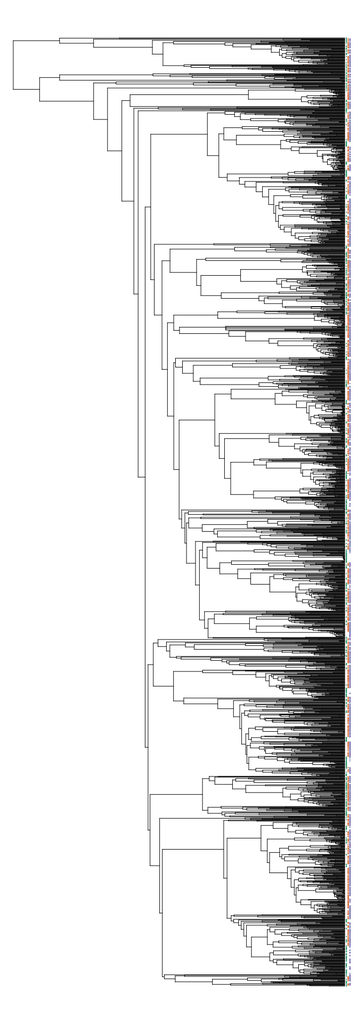

```r
plot(phy, show.tip.label = FALSE, no.margin = TRUE)
obj <- get("last_plot.phylo", .PlotPhyloEnv)

matr <- t(sample_matrix)[phy$tip.label, ]
xx <- obj$xx[1:obj$Ntip]
yy <- obj$yy[1:obj$Ntip]
cols <- c("#1b9e77", "#d95f02", "#7570b3")
for (ii in 1:ncol(matr)) {
  present_idx <- matr[, ii] == 1
  points(xx[present_idx] + ii, yy[present_idx], col = cols[ii], cex = 0.1)
}
```